# Project Python Foundations: FoodHub Data Analysis

### **Question 12**: Perform a multivariate analysis to explore relationships between the important variables in the dataset. (It is a good idea to explore relations between numerical variables as well as relations between numerical and categorical variables) [10 marks]

**Cuisine Vs Cost of the Order**

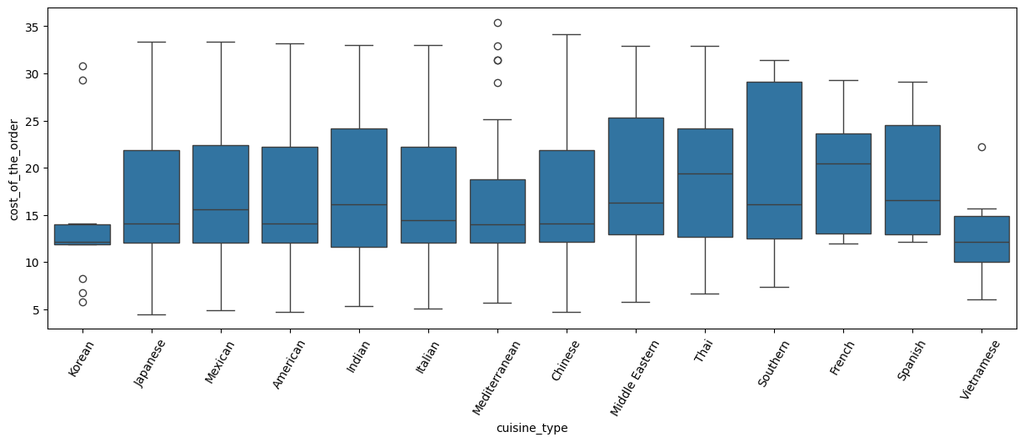

```python
# Relationship between cost of the order and cuisine type using Boxplot
plt.figure(figsize=(15,5))
sns.boxplot(data=df,x='cuisine_type',y='cost_of_the_order')
plt.xticks(rotation=60)
plt.show()
```

#### Observations

- Outliers are presents in Korean,mediterranean and Vietnamese cuisines.
- French and Spanish are expensive compared to other cuisines.
- Vietnamese and Korean cuisines cost less than other cuisines.
- The boxplot for American, Italian,chinese, Japanese cuisines are quite similar.

**Cuisines Vs Food Preparation Time**

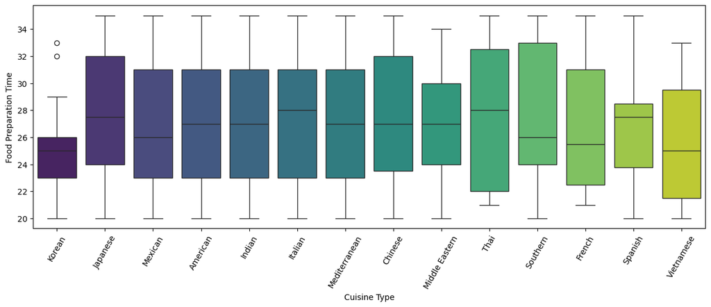

```python
# Relationship between Cuisines and Food preparation Time using boxplot
plt.figure(figsize=(15,5))
sns.boxplot(data=df,x='cuisine_type',y='food_preparation_time', palette='viridis')
plt.xlabel('Cuisine Type')
plt.ylabel('Food Preparation Time')
plt.xticks(rotation=60)
plt.show()
```

#### Observarions

- The median food prepartion time lies between 24 to 30 minutes for all the cuisines
- Outliers are presents for the food preparation time for korean cuisine.
- Korean cuisine takes less preparation time than others and for most of the cuisine food preparation time is very consistent.

**Cuisine Vs Food delivery time**

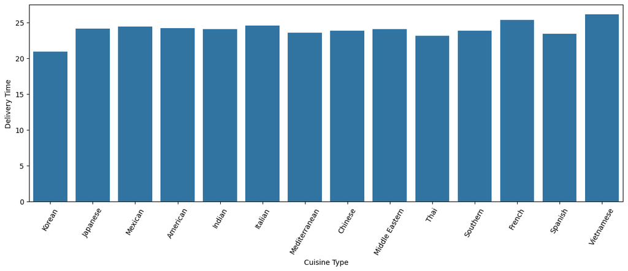

```python
# Ralationship between cuisine and their delivery time
plt.figure(figsize=(15,5))
sns.barplot(data=df,x='cuisine_type',y='delivery_time',errorbar=None)
plt.xlabel('Cuisine Type')
plt.ylabel('Delivery Time')
plt.xticks(rotation=60)
plt.show()
```

#### Observations

- Vietnamese and french takes more 25 min to delivery the order.
- Korean cuisine around 20 min which is less than other cuisines delivery time.

**Delivery Time Vs Day of the week**

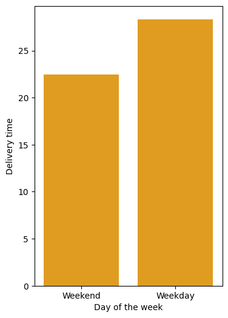

```python
# Relationship between delivery time and Day of the week using barplot
plt.figure(figsize=(4,6))
sns.barplot(data=df,x='day_of_the_week',y='delivery_time', errorbar=None, color='orange')
plt.xlabel('Day of the week')
plt.ylabel('Delivery time')
plt.show()
```

#### Observation

- The Weekend delivery time for all the orders is less than weekdays orders, this could be less traffic over the weekends.

**Revenue generated by the restaurant**

```python
plt.figure(figsize=(10,5))
df.groupby(['restaurant_name'])['cost_of_the_order'].sum().sort_values(ascending=False).head(14)
```

| restaurant_name | cost_of_the_order |
| --- | --- |
| Shake Shack | 3579.53 |
| The Meatball Shop | 2145.21 |
| Blue Ribbon Sushi | 1903.95 |
| Blue Ribbon Fried Chicken | 1662.29 |
| Parm | 1112.76 |
| RedFarm Broadway | 965.13 |
| RedFarm Hudson | 921.21 |
| TAO | 834.50 |
| Han Dynasty | 755.29 |
| Blue Ribbon Sushi Bar & Grill | 666.62 |
| Rubirosa | 660.45 |
| Sushi of Gari 46 | 640.87 |
| Nobu Next Door | 623.67 |
| Five Guys Burgers and Fries | 506.47 |

**dtype:** float64

#### Observations

- In this dataset there are 14 restaurants which has more than 500 dollars revenue.

**Rating Vs Delivery Time**

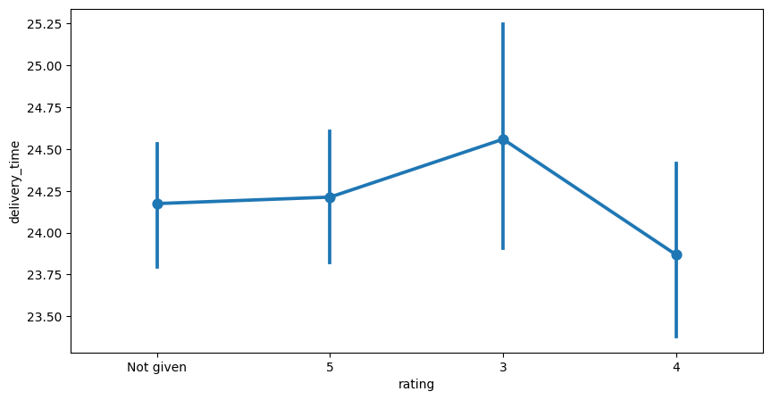

```python
#Relationship between rating and delivery time using pointplot
plt.figure(figsize=(10,5))
sns.pointplot(data=df,x='rating',y='delivery_time')
plt.show()
```

#### Observations

**Rating Vs Food Preparation time**

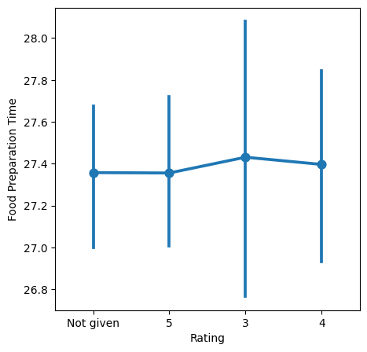

```python
#Relationship between rating and food prepartion time
plt.figure(figsize=(5,5))
sns.pointplot(data=df,x='rating',y='food_preparation_time')
plt.xlabel('Rating')
plt.ylabel('Food Preparation Time')
plt.show()
```

#### Observation

- Food preparation time does not affect in the low rating of orders.

**Rating Vs Cost of order**

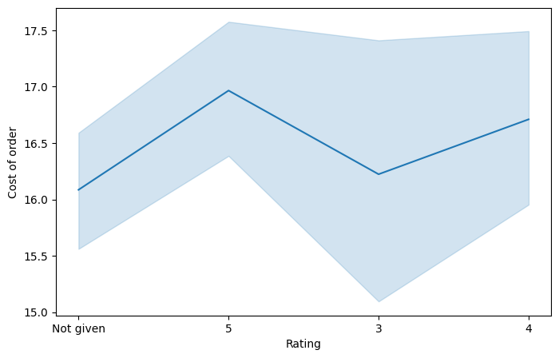

```python
# Relationship between rating and cost of order
plt.figure(figsize=(8,5))
sns.lineplot(data=df,x='rating',y='cost_of_the_order')
plt.xlabel('Rating')
plt.ylabel('Cost of order')
plt.show()
```

#### Observations

**Pairplot** a pairplot helps the visualization the relationship between each pair of numerical variable in dataset

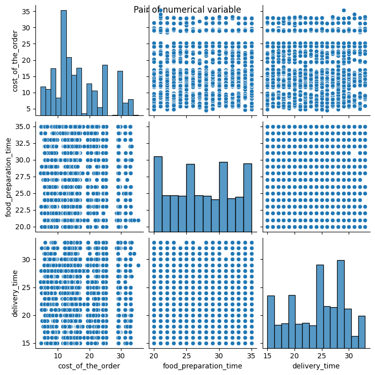

```python
sns.pairplot(df[['cost_of_the_order','food_preparation_time','delivery_time']])
plt.suptitle('Pair of numerical variable',verticalalignment='top')
plt.show()
```

**Correlation amongs variables**

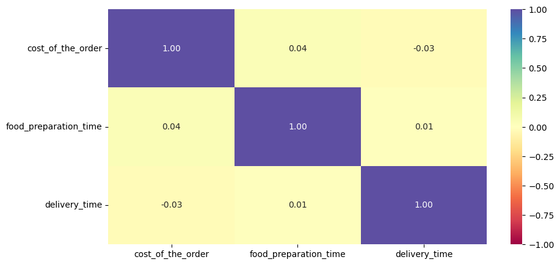

```python
# Plotting the heatmap
cols_list=['cost_of_the_order','food_preparation_time','delivery_time']
plt.figure(figsize=(10,5))
sns.heatmap(df[cols_list].corr(),annot=True, fmt=".2f",vmin=-1,vmax=1,cmap='Spectral')
plt.show()
```

#### Observations

- There is no correlation between Cost of order, food preparation time and delivery time.

### **Question 13:** The company wants to provide a promotional offer in the advertisement of the restaurants. The condition to get the offer is that the restaurants must have a rating count of more than 50 and the average rating should be greater than 4. Find the restaurants fulfilling the criteria to get the promotional offer. [3 marks]

```python
# Write the code here
# first get all restaurants who has ratings
df_rated=df[df['rating']!='Not given'].copy()
# covert the rating column from object to int
df_rated['rating']=df_rated['rating'].astype(int)
# creating a dataframe with restaurant name and rating counts
df_count=df_rated.groupby(['restaurant_name'])['rating'].count().sort_values(ascending=False).reset_index()
df_count.head()
```

|  | restaurant_name | rating |
| --- | --- | --- |
| 0 | Shake Shack | 133 |
| 1 | The Meatball Shop | 84 |
| 2 | Blue Ribbon Sushi | 73 |
| 3 | Blue Ribbon Fried Chicken | 64 |
| 4 | RedFarm Broadway | 41 |

```python
# Get restaurant names that have rating count more than 50
rest_names=df_count[df_count['rating']>50]['restaurant_name'].to_list()
# get the data from df_count for rest name list restaurants
df_promo=df_rated[df_rated['restaurant_name'].isin(rest_names)].copy()
# find the mean rating of the restaurants
df_promo.groupby(df_promo['restaurant_name'])['rating'].mean().sort_values(ascending=False).reset_index()
```

|  | restaurant_name | rating |
| --- | --- | --- |
| 0 | The Meatball Shop | 4.511905 |
| 1 | Blue Ribbon Fried Chicken | 4.328125 |
| 2 | Shake Shack | 4.278195 |
| 3 | Blue Ribbon Sushi | 4.219178 |

#### Observations:

- The restaurants fullfill the criteria to get the promotional offer are:- **The Meatball Shop, Blue Ribbon Fried Chicken,Shake shack, Blue Ribbon sushi**

### **Question 14:** The company charges the restaurant 25% on the orders having cost greater than 20 dollars and 15% on the orders having cost greater than 5 dollars. Find the net revenue generated by the company across all orders. [3 marks]

```python
# Write the code here
# using function to find out net revenue
def net_revenue(x):
  if x>20:
    return x*0.25
  elif x>5:
    return x*0.15
  else:
    return x*0
df['Net_revenue']=df['cost_of_the_order'].apply(net_revenue)
df.head()
```

|  | order_id | customer_id | restaurant_name | cuisine_type | cost_of_the_order | day_of_the_week | rating | food_preparation_time | delivery_time | Net_revenue |
| --- | --- | --- | --- | --- | --- | --- | --- | --- | --- | --- |
| 0 | 1477147 | 337525 | Hangawi | Korean | 30.75 | Weekend | Not given | 25 | 20 | 7.6875 |
| 1 | 1477685 | 358141 | Blue Ribbon Sushi Izakaya | Japanese | 12.08 | Weekend | Not given | 25 | 23 | 1.8120 |
| 2 | 1477070 | 66393 | Cafe Habana | Mexican | 12.23 | Weekday | 5 | 23 | 28 | 1.8345 |
| 3 | 1477334 | 106968 | Blue Ribbon Fried Chicken | American | 29.20 | Weekend | 3 | 25 | 15 | 7.3000 |
| 4 | 1478249 | 76942 | Dirty Bird to Go | American | 11.59 | Weekday | 4 | 25 | 24 | 1.7385 |

```python
# get the total revenue and print
total_rev=df['Net_revenue'].sum()
print("The total revenue generated by the company is",round(total_rev,2),'dollars')
```

```
The total revenue generated by the company is 6166.3 dollars
```

#### Observations:

The Total venue generated by the company is **6166.3** dollars

### **Question 15:** The company wants to analyze the total time required to deliver the food. What percentage of orders take more than 60 minutes to get delivered from the time the order is placed? (The food has to be prepared and then delivered.) [2 marks]

```python
# Write the code here
# adding the new column which saves total delivery time
df['total_time']=df['food_preparation_time']+df['delivery_time']
# find the percentage of orders that have more than 60 mins of total deliery time
total_percentage=df[df['total_time']>60].shape[0]/df.shape[0]*100
print(round(total_percentage,2),'% of orders take more than 60 minutes to get delivered')
```

```
10.54 % of orders take more than 60 minutes to get delivered
```

#### Observations:

- Approximtely 10.54% of the total orders have more than 60 mins of total time.

### **Question 16:** The company wants to analyze the delivery time of the orders on weekdays and weekends. How does the mean delivery time vary during weekdays and weekends? [2 marks]

```python
# get the mean delivery time of weekdays
print("Mean delivery time on weekdays:-",round(df[df['day_of_the_week']=='Weekday']['delivery_time'].mean()),'minutes')
# get the mean delivery time of weekends
print("Mean delivery time on weekends:-",round(df[df['day_of_the_week']=='Weekend']['delivery_time'].mean()),'minutes')
```

```
Mean delivery time on weekdays:- 28 minutes
Mean delivery time on weekends:- 22 minutes
```

#### Observations:

- The mean delivery time for weekdays is around 28 mins
- The mean delivery time for weekends is around 22 mins
- Delivery during weekdays take on average almost 6 mins longer than during weekends

### Recommendations:

- Food hub should provide promotional offers to top rated popular restaurants like shake shake that serves most of the orders.
- As the order volumn is high during the weekends, more delivery persons should be employed during the weekends to ensure timely delivery ofthe order.
- Weekend promotional offers should be given to the customer to increase the food orders during weekends.
- The should investigate the reason behind the low count of ratings, they can redesign the rating page in app and make it more atrractive.
- Since American , Japanese cuisine types are the most popular in terms of the no of order placed, incorporating more restaurants that promotes these cuisines types can help increase the no of orders through food hub.
- There are more orders who have more than 60 mins of delivery time.Food hub should try to minimize such instance by rewarding punchual delivery person to avoid customer dissatifaction.